# Table of Contents

A股投资者结构总览

# 一、组成

## 1.上证所总市值口径

计算方法：Wind EDB-投资者持股市值4项

## 2.流通市值口径

计算方法

- A股流通总市值：中国A股日行情估值指标：当日流通市值，当日全部股票加总
- 一般法人：中国A股前十大流通股东中非金融类的其他股东，持有数量*当日收盘价
- 散户：轧差项
- 大股东：中国A股前十大流通股东中股东类型为个人，持有数量*当日收盘价
- 国家队：中国A股前十大流通股东中股东名称为国家队公司，持有数量*当日收盘价
- 公募基金：取全部初始基金，中国共同基金投资组合——资产配置：持有股票市值(元)-港股通投资港股市值，每季度加总
- 私募基金：2015-06-30之前，采用中国A股前十大流通股东中股东名称包含“私募”或“资金信托计划”，持有数量*当日收盘价，除以0.05为全部持股市值；2015-06-30之后，采用私募基金管理机构:实缴规模:私募证券投资基金*仓位估计持股市值，2015、2017年仓位为0.8，2021-12-31仓位为0.75，2022-03-31仓位为0.65，其余时间仓位为0.6
- 险资
  - 保险：采用保险资金运用余额中分项计算，2013-06-30之前的股票和证券投资部分，采用2013-06-30的股票和证券投资与投资之比*对应时间投资部分；2013-06-30及之后采用股票和证券投资部分；因为其中不仅含有股票，股票和证券投资部分*0.575为投资向股票的市值
  - 社保：中国A股前十大流通股东中股东名称为3种社保基金投资渠道，持有数量*当日收盘价，整体求和后/0.4
- 外资：2013-12-31之前，采用外资持股在中国A股前十大流通股东中的总流通市值，乘上其和总持股的比例（通过2014-03-31数据估计）；2013-12-31及之后采用境外机构和个人持有境内资产-股票指标
- 其他机构
  - 年金：中国A股前十大流通股东中股东名称包含“年金”，持有数量*当日收盘价
  - 信托：中国A股前十大流通股东中股东名称包含“信托”且不包含“专户”，持有数量*当日收盘价
  - 券商资管及自营：中国A股前十大流通股东中股东名称包含“证券”且不包含“回购”，持有数量*当日收盘价
  - 银行：中国A股前十大流通股东中股东名称包含“银行”且不包含“-”（去除资管产品），持有数量*当日收盘价

# 二、交易情况

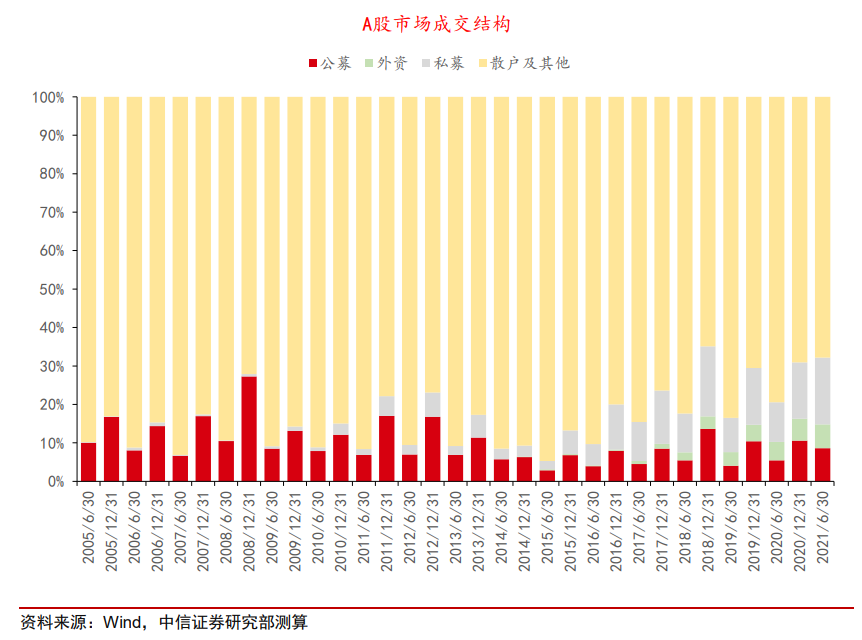